# titanic-the-savior_Kfgflipynb

## Get started

```python
# This Python 3 environment comes with many helpful analytics libraries installed
# It is defined by the kaggle/python Docker image: https://github.com/kaggle/docker-python
# For example, here's several helpful packages to load

import numpy as np # linear algebra
import pandas as pd # data processing, CSV file I/O (e.g. pd.read_csv)
import matplotlib.pyplot as plt
import seaborn as sns
!pip install category_encoders
# Input data files are available in the read-only "../input/" directory
# For example, running this (by clicking run or pressing Shift+Enter) will list all files under the input directory
'''
import os
for dirname, _, filenames in os.walk('/kaggle/input'):
    for filename in filenames:
        print(os.path.join(dirname, filename))
'''
# You can write up to 20GB to the current directory (/kaggle/working/) that gets preserved as output when you create a version using "Save & Run All"
# You can also write temporary files to /kaggle/temp/, but they won't be saved outside of the current session
```

```
     |████████████████████████████████| 82 kB 452 kB/s
```

```
"\nimport os\nfor dirname, _, filenames in os.walk('/kaggle/input'):\n    for filename in filenames:\n        print(os.path.join(dirname, filename))\n"
```

```python
"""kaggle_location='../input/titanic/train.csv'
df=pd.read_csv(kaggle_location,index_col="PassengerId")"""
```

```
'kaggle_location=\'../input/titanic/train.csv\'\ndf=pd.read_csv(kaggle_location,index_col="PassengerId")'
```

```python
drive_train_location='/content/drive/MyDrive/Colab Notebooks/titanic_survived/train.csv'
df=pd.read_csv(drive_train_location,index_col="PassengerId")
```

## Data preparation

```python
df.head()
```

| PassengerId | Survived | Pclass | Name | Sex | Age | SibSp | Parch | Ticket | Fare | Cabin | Embarked |
| --- | --- | --- | --- | --- | --- | --- | --- | --- | --- | --- | --- |
| 1 | 0 | 3 | Braund, Mr. Owen Harris | male | 22.0 | 1 | 0 | A/5 21171 | 7.2500 | NaN | S |
| 2 | 1 | 1 | Cumings, Mrs. John Bradley (Florence Briggs Th... | female | 38.0 | 1 | 0 | PC 17599 | 71.2833 | C85 | C |
| 3 | 1 | 3 | Heikkinen, Miss. Laina | female | 26.0 | 0 | 0 | STON/O2. 3101282 | 7.9250 | NaN | S |
| 4 | 1 | 1 | Futrelle, Mrs. Jacques Heath (Lily May Peel) | female | 35.0 | 1 | 0 | 113803 | 53.1000 | C123 | S |
| 5 | 0 | 3 | Allen, Mr. William Henry | male | 35.0 | 0 | 0 | 373450 | 8.0500 | NaN | S |

```python
df.tail()
```

| PassengerId | Survived | Pclass | Name | Sex | Age | SibSp | Parch | Ticket | Fare | Cabin | Embarked |
| --- | --- | --- | --- | --- | --- | --- | --- | --- | --- | --- | --- |
| 887 | 0 | 2 | Montvila, Rev. Juozas | male | 27.0 | 0 | 0 | 211536 | 13.00 | NaN | S |
| 888 | 1 | 1 | Graham, Miss. Margaret Edith | female | 19.0 | 0 | 0 | 112053 | 30.00 | B42 | S |
| 889 | 0 | 3 | Johnston, Miss. Catherine Helen "Carrie" | female | NaN | 1 | 2 | W./C. 6607 | 23.45 | NaN | S |
| 890 | 1 | 1 | Behr, Mr. Karl Howell | male | 26.0 | 0 | 0 | 111369 | 30.00 | C148 | C |
| 891 | 0 | 3 | Dooley, Mr. Patrick | male | 32.0 | 0 | 0 | 370376 | 7.75 | NaN | Q |

```python
df.Name.head(20)
```

```
PassengerId
1                               Braund, Mr. Owen Harris
2     Cumings, Mrs. John Bradley (Florence Briggs Th...
3                                Heikkinen, Miss. Laina
4          Futrelle, Mrs. Jacques Heath (Lily May Peel)
5                              Allen, Mr. William Henry
6                                      Moran, Mr. James
7                               McCarthy, Mr. Timothy J
8                        Palsson, Master. Gosta Leonard
9     Johnson, Mrs. Oscar W (Elisabeth Vilhelmina Berg)
10                  Nasser, Mrs. Nicholas (Adele Achem)
11                      Sandstrom, Miss. Marguerite Rut
12                             Bonnell, Miss. Elizabeth
13                       Saundercock, Mr. William Henry
14                          Andersson, Mr. Anders Johan
15                 Vestrom, Miss. Hulda Amanda Adolfina
16                     Hewlett, Mrs. (Mary D Kingcome)
17                                 Rice, Master. Eugene
18                         Williams, Mr. Charles Eugene
19    Vander Planke, Mrs. Julius (Emelia Maria Vande...
20                              Masselmani, Mrs. Fatima
Name: Name, dtype: object
```

```python
df.describe()
```

|  | Survived | Pclass | Age | SibSp | Parch | Fare |
| --- | --- | --- | --- | --- | --- | --- |
| count | 891.000000 | 891.000000 | 714.000000 | 891.000000 | 891.000000 | 891.000000 |
| mean | 0.383838 | 2.308642 | 29.699118 | 0.523008 | 0.381594 | 32.204208 |
| std | 0.486592 | 0.836071 | 14.526497 | 1.102743 | 0.806057 | 49.693429 |
| min | 0.000000 | 1.000000 | 0.420000 | 0.000000 | 0.000000 | 0.000000 |
| 25% | 0.000000 | 2.000000 | 20.125000 | 0.000000 | 0.000000 | 7.910400 |
| 50% | 0.000000 | 3.000000 | 28.000000 | 0.000000 | 0.000000 | 14.454200 |
| 75% | 1.000000 | 3.000000 | 38.000000 | 1.000000 | 0.000000 | 31.000000 |
| max | 1.000000 | 3.000000 | 80.000000 | 8.000000 | 6.000000 | 512.329200 |

```python
df.info()
```

```
<class 'pandas.core.frame.DataFrame'>
Int64Index: 891 entries, 1 to 891
Data columns (total 11 columns):
 #   Column    Non-Null Count  Dtype
---  ------    --------------  -----
 0   Survived  891 non-null    int64
 1   Pclass    891 non-null    int64
 2   Name      891 non-null    object
 3   Sex       891 non-null    object
 4   Age       714 non-null    float64
 5   SibSp     891 non-null    int64
 6   Parch     891 non-null    int64
 7   Ticket    891 non-null    object
 8   Fare      891 non-null    float64
 9   Cabin     204 non-null    object
 10  Embarked  889 non-null    object
dtypes: float64(2), int64(4), object(5)
memory usage: 83.5+ KB
```

```python
"""missing entries for """
df.loc[df.Age.isnull()]
```

| PassengerId | Survived | Pclass | Name | Sex | Age | SibSp | Parch | Ticket | Fare | Cabin | Embarked |
| --- | --- | --- | --- | --- | --- | --- | --- | --- | --- | --- | --- |
| 6 | 0 | 3 | Moran, Mr. James | male | NaN | 0 | 0 | 330877 | 8.4583 | NaN | Q |
| 18 | 1 | 2 | Williams, Mr. Charles Eugene | male | NaN | 0 | 0 | 244373 | 13.0000 | NaN | S |
| 20 | 1 | 3 | Masselmani, Mrs. Fatima | female | NaN | 0 | 0 | 2649 | 7.2250 | NaN | C |
| 27 | 0 | 3 | Emir, Mr. Farred Chehab | male | NaN | 0 | 0 | 2631 | 7.2250 | NaN | C |
| 29 | 1 | 3 | O'Dwyer, Miss. Ellen "Nellie" | female | NaN | 0 | 0 | 330959 | 7.8792 | NaN | Q |
| ... | ... | ... | ... | ... | ... | ... | ... | ... | ... | ... | ... |
| 860 | 0 | 3 | Razi, Mr. Raihed | male | NaN | 0 | 0 | 2629 | 7.2292 | NaN | C |
| 864 | 0 | 3 | Sage, Miss. Dorothy Edith "Dolly" | female | NaN | 8 | 2 | CA. 2343 | 69.5500 | NaN | S |
| 869 | 0 | 3 | van Melkebeke, Mr. Philemon | male | NaN | 0 | 0 | 345777 | 9.5000 | NaN | S |
| 879 | 0 | 3 | Laleff, Mr. Kristo | male | NaN | 0 | 0 | 349217 | 7.8958 | NaN | S |
| 889 | 0 | 3 | Johnston, Miss. Catherine Helen "Carrie" | female | NaN | 1 | 2 | W./C. 6607 | 23.4500 | NaN | S |

177 rows × 11 columns

```python
'''How many people die from that missing [177-125 die =52 Survived] '''

df.loc[(df.Age.isnull()) & (df.Survived == 0)]
```

| PassengerId | Survived | Pclass | Name | Sex | Age | SibSp | Parch | Ticket | Fare | Cabin | Embarked |
| --- | --- | --- | --- | --- | --- | --- | --- | --- | --- | --- | --- |
| 6 | 0 | 3 | Moran, Mr. James | male | NaN | 0 | 0 | 330877 | 8.4583 | NaN | Q |
| 27 | 0 | 3 | Emir, Mr. Farred Chehab | male | NaN | 0 | 0 | 2631 | 7.2250 | NaN | C |
| 30 | 0 | 3 | Todoroff, Mr. Lalio | male | NaN | 0 | 0 | 349216 | 7.8958 | NaN | S |
| 43 | 0 | 3 | Kraeff, Mr. Theodor | male | NaN | 0 | 0 | 349253 | 7.8958 | NaN | C |
| 46 | 0 | 3 | Rogers, Mr. William John | male | NaN | 0 | 0 | S.C./A.4. 23567 | 8.0500 | NaN | S |
| ... | ... | ... | ... | ... | ... | ... | ... | ... | ... | ... | ... |
| 860 | 0 | 3 | Razi, Mr. Raihed | male | NaN | 0 | 0 | 2629 | 7.2292 | NaN | C |
| 864 | 0 | 3 | Sage, Miss. Dorothy Edith "Dolly" | female | NaN | 8 | 2 | CA. 2343 | 69.5500 | NaN | S |
| 869 | 0 | 3 | van Melkebeke, Mr. Philemon | male | NaN | 0 | 0 | 345777 | 9.5000 | NaN | S |
| 879 | 0 | 3 | Laleff, Mr. Kristo | male | NaN | 0 | 0 | 349217 | 7.8958 | NaN | S |
| 889 | 0 | 3 | Johnston, Miss. Catherine Helen "Carrie" | female | NaN | 1 | 2 | W./C. 6607 | 23.4500 | NaN | S |

125 rows × 11 columns

```python
'''Age of Survived people '''
df.Age[df.Survived==1].describe()
```

```
count    290.000000
mean      28.343690
std       14.950952
min        0.420000
25%       19.000000
50%       28.000000
75%       36.000000
max       80.000000
Name: Age, dtype: float64
```

```python
df.Embarked.unique()
```

```
array(['S', 'C', 'Q', nan], dtype=object)
```

```python
df.Embarked.value_counts()
```

```
S    644
C    168
Q     77
Name: Embarked, dtype: int64
```

```python
df.Embarked.isnull().sum()
```

```
2
```

```python
df.info()
```

```
<class 'pandas.core.frame.DataFrame'>
Int64Index: 891 entries, 1 to 891
Data columns (total 11 columns):
 #   Column    Non-Null Count  Dtype
---  ------    --------------  -----
 0   Survived  891 non-null    int64
 1   Pclass    891 non-null    int64
 2   Name      891 non-null    object
 3   Sex       891 non-null    object
 4   Age       714 non-null    float64
 5   SibSp     891 non-null    int64
 6   Parch     891 non-null    int64
 7   Ticket    891 non-null    object
 8   Fare      891 non-null    float64
 9   Cabin     204 non-null    object
 10  Embarked  889 non-null    object
dtypes: float64(2), int64(4), object(5)
memory usage: 83.5+ KB
```

df.drop(['Ticket','Cabin','Name'],inplace=True,axis=1) df.dropna(axis=0)

```python
def data_filter(df):
    df.drop(['Ticket','Cabin','Name','Age','SibSp','Parch','Embarked'],inplace=True,axis=1)
    #df.Age.fillna(25,inplace=True) ## 25
    #df.Embarked.fillna('N',inplace=True) # Q
    #df.dropna(axis=0,inplace=True)
    return df
```

```python
df=data_filter(df)
```

```python
df.describe()
```

|  | Survived | Pclass | Fare |
| --- | --- | --- | --- |
| count | 891.000000 | 891.000000 | 891.000000 |
| mean | 0.383838 | 2.308642 | 32.204208 |
| std | 0.486592 | 0.836071 | 49.693429 |
| min | 0.000000 | 1.000000 | 0.000000 |
| 25% | 0.000000 | 2.000000 | 7.910400 |
| 50% | 0.000000 | 3.000000 | 14.454200 |
| 75% | 1.000000 | 3.000000 | 31.000000 |
| max | 1.000000 | 3.000000 | 512.329200 |

## Data Visualization

plt.figure(figsize=(10,6)) sns.barplot(y=df.Survived,x=df.Embarked,hue=df.Sex,)

plt.figure(figsize=(10,6)) g=sns.barplot(y=df.Survived,x=df.Embarked,hue=df.Sex,) ticks=[0,1] g.set_yticks(ticks) g.set_yticklabels(ticks)

```python
#sns.distplot(a=df['Age'], kde=True)
```

```python
#sns.jointplot(x=df['Age'], y=df['Survived'], kind="kde")
```

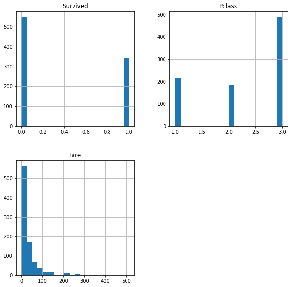

```python
df.hist(bins=20, figsize=(10, 10))
plt.show()
```

```python
corr_mat=df.corr()
corr_mat['Survived'].sort_values(ascending=True)
```

```
Pclass     -0.338481
Fare        0.257307
Survived    1.000000
Name: Survived, dtype: float64
```

## Feature Engg.

```python
df.head()
```

| PassengerId | Survived | Pclass | Sex | Fare |
| --- | --- | --- | --- | --- |
| 1 | 0 | 3 | male | 7.2500 |
| 2 | 1 | 1 | female | 71.2833 |
| 3 | 1 | 3 | female | 7.9250 |
| 4 | 1 | 1 | female | 53.1000 |
| 5 | 0 | 3 | male | 8.0500 |

from category_encoders import OrdinalEncoder maplist=[{'col':'Sex','mapping':{'male':0,'female':1}},{'col':'Embarked','mapping':{'S':0,'C':1,'Q':2}}] ordinal_encoder=OrdinalEncoder(mapping=maplist) df=ordinal_encoder.fit_transform(df)

```python
from category_encoders import OrdinalEncoder
maplist=[{'col':'Sex','mapping':{'male':0,'female':1}}]
ordinal_encoder=OrdinalEncoder(mapping=maplist)
df=ordinal_encoder.fit_transform(df)
```

```python
df.describe()
```

|  | Survived | Pclass | Sex | Fare |
| --- | --- | --- | --- | --- |
| count | 891.000000 | 891.000000 | 891.000000 | 891.000000 |
| mean | 0.383838 | 2.308642 | 0.352413 | 32.204208 |
| std | 0.486592 | 0.836071 | 0.477990 | 49.693429 |
| min | 0.000000 | 1.000000 | 0.000000 | 0.000000 |
| 25% | 0.000000 | 2.000000 | 0.000000 | 7.910400 |
| 50% | 0.000000 | 3.000000 | 0.000000 | 14.454200 |
| 75% | 1.000000 | 3.000000 | 1.000000 | 31.000000 |
| max | 1.000000 | 3.000000 | 1.000000 | 512.329200 |

```python
corr_mat=df.corr()
corr_mat['Survived'].sort_values(ascending=True)
```

```
Pclass     -0.338481
Fare        0.257307
Sex         0.543351
Survived    1.000000
Name: Survived, dtype: float64
```

from sklearn.preprocessing import OneHotEncoder def OH_Custom(df): OH_encoder = OneHotEncoder(handle_unknown='ignore', sparse=False) OH_Cat= pd.DataFrame(OH_encoder.fit_transform(df.loc[:,['Sex','Embarked']]),columns=['Sex_M','Sex_F','Embarked_C','Embarked_Q','Embarked_S']) df=df.join(OH_Cat) df.drop(['Sex','Embarked'],axis=1,inplace=True) return df

df.iloc[885:891]

df=OH_Custom(df)

df.iloc[885:891]

## Spliting train-Validation

```python
features=df.drop('Survived',axis=1)
features
```

| PassengerId | Pclass | Sex | Fare |
| --- | --- | --- | --- |
| 1 | 3 | 0 | 7.2500 |
| 2 | 1 | 1 | 71.2833 |
| 3 | 3 | 1 | 7.9250 |
| 4 | 1 | 1 | 53.1000 |
| 5 | 3 | 0 | 8.0500 |
| ... | ... | ... | ... |
| 887 | 2 | 0 | 13.0000 |
| 888 | 1 | 1 | 30.0000 |
| 889 | 3 | 1 | 23.4500 |
| 890 | 1 | 0 | 30.0000 |
| 891 | 3 | 0 | 7.7500 |

891 rows × 3 columns

```python
label=df.pop('Survived')
label
```

```
PassengerId
1      0
2      1
3      1
4      1
5      0
      ..
887    0
888    1
889    0
890    1
891    0
Name: Survived, Length: 891, dtype: int64
```

```python
from sklearn.model_selection import train_test_split
```

```python
train_X, val_X, train_y, val_y = train_test_split(features, label, random_state = 0)
```

## Model

```python
from sklearn.preprocessing import StandardScaler
from sklearn.ensemble import RandomForestClassifier
from sklearn.pipeline import Pipeline
from sklearn.model_selection import GridSearchCV
from xgboost import XGBClassifier
from sklearn.metrics import mean_squared_error
```

### GridSearchCv

```python
'''model=RandomForestClassifier(random_state=42)
params={'n_estimators':[50, 70, 100, 250, 1000],
        'max_leaf_nodes':[2, 4, 6, 8],
        'max_samples':[5,6, 10, 11, 12, 15,20],

        }
gs=GridSearchCV(estimator=model, param_grid=params, cv=10,n_jobs = -1,verbose=1,scoring='accuracy')
gs = gs.fit(train_X, train_y) '''
```

[output not shown]

```python
"""model = XGBClassifier()


params={'n_estimators':[50, 70, 100, 250, 1000],
        'learning_rate':[0.05,0.0001,0.01,0.1],
        }
gs=GridSearchCV(estimator=model, param_grid=params, cv=10,n_jobs = -1,verbose=1,scoring='accuracy')
gs = gs.fit(train_X, train_y)"""
```

```
"model = XGBClassifier()\n\n\nparams={'n_estimators':[50, 70, 100, 250, 1000], \n        'learning_rate':[0.05,0.0001,0.01,0.1],  \n        }\ngs=GridSearchCV(estimator=model, param_grid=params, cv=10,n_jobs = -1,verbose=1,scoring='accuracy')\ngs = gs.fit(train_X, train_y)"
```

```python
"""best_params=gs.best_params_
accuracy=gs.best_score_
print(best_params)
print(accuracy)"""
```

```
'best_params=gs.best_params_\naccuracy=gs.best_score_\nprint(best_params)\nprint(accuracy)'
```

### RandomForest

"""RMSE on train data: 0.4273578483413194 RMSE on train data: 0.46394680381623543 """

model_pipeline = Pipeline(steps=[('pre_processing',StandardScaler()), ('random_forest',RandomForestClassifier(max_leaf_nodes= 6, max_samples=20, n_estimators=50,random_state=42)) ])